# Simple Multi-Class Classification Model for [Project Name] Using Python

### 2.b) Data visualizations

##### 2.b.i) Univariate plots to better understand each attribute

```python
attributeOnly = entireDataset.drop(columns=['targetVar'])
```

```python
# Set figure width to 16 and height to 12 (4:3 aspect ratio)
fig_size = pyplot.rcParams["figure.figsize"]
fig_size[0] = 16
fig_size[1] = 12
pyplot.rcParams["figure.figsize"] = fig_size
```

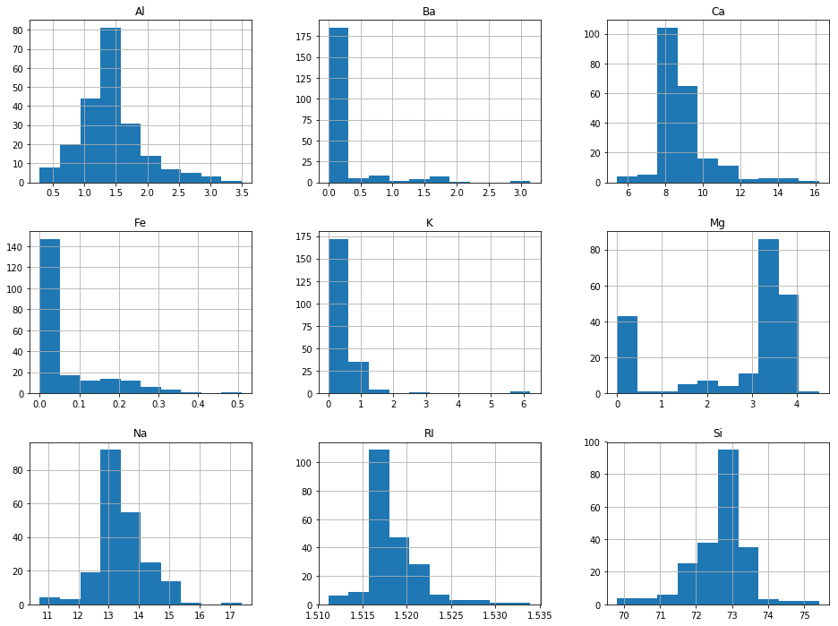

```python
# Histograms for each attribute
attributeOnly.hist()
pyplot.show()
```

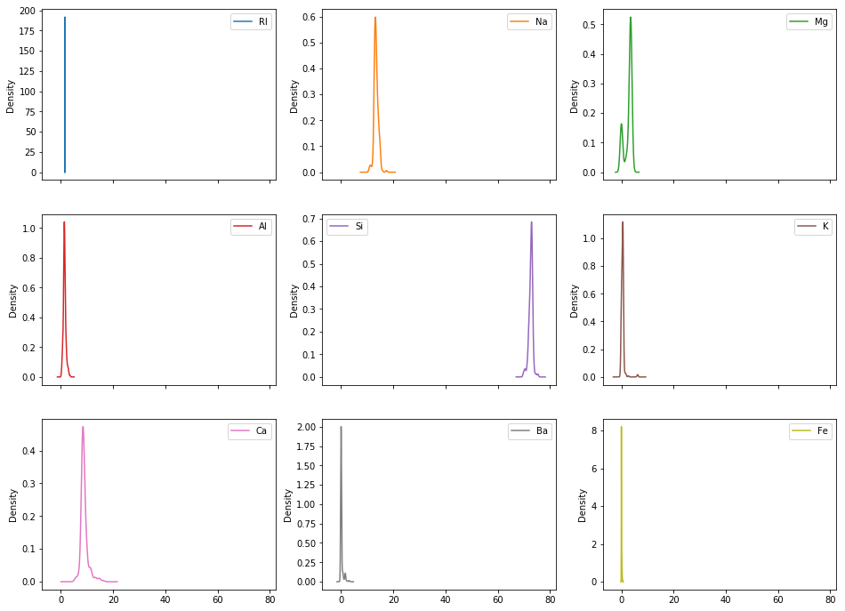

```python
# Density plot for each attribute
attributeOnly.plot(kind='density', subplots=True, layout=(dispRow,dispCol))
pyplot.show()
```

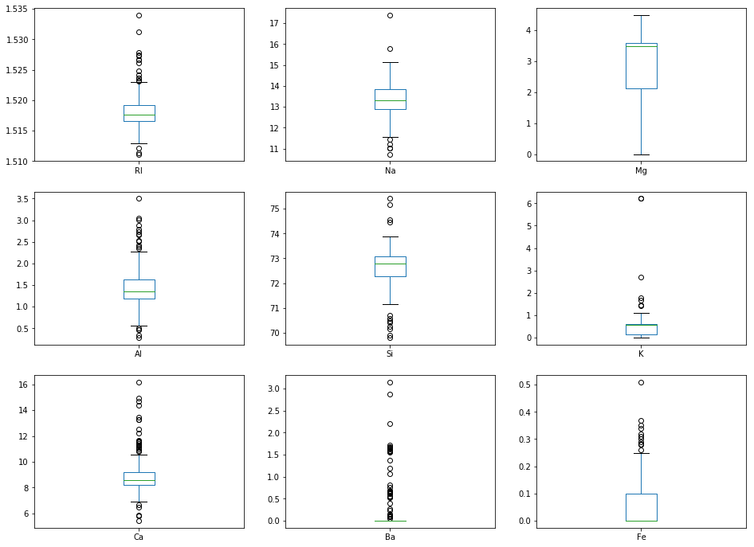

```python
# Box and Whisker plot for each attribute
attributeOnly.plot(kind='box', subplots=True, layout=(dispRow,dispCol))
pyplot.show()
```

#### 2.b.ii) Multivariate plots to better understand the relationships between attributes

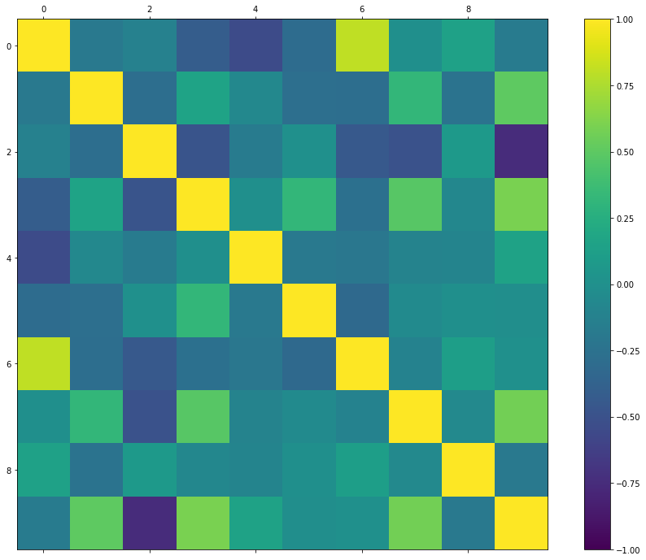

```python
# Correlation matrix
fig = pyplot.figure()
ax = fig.add_subplot(111)
cax = ax.matshow(entireDataset.corr(), vmin=-1, vmax=1)
fig.colorbar(cax)
pyplot.show()
```

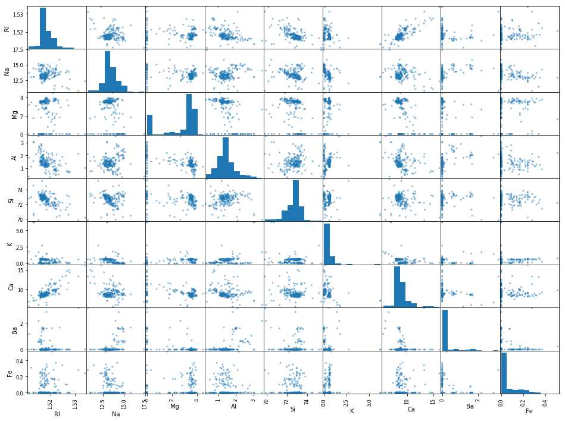

```python
# Scatterplot matrix
scatter_matrix(attributeOnly)
pyplot.show()
```

## Section 3 - Prepare Data

Some dataset may require additional preparation activities that will best exposes the structure of the problem and the relationships between the input attributes and the output variable. Some data-prep tasks might include:

- Cleaning data by removing duplicates, marking missing values and even imputing missing values.
- Feature selection where redundant features may be removed.
- Data transforms where attributes are scaled or redistributed in order to best expose the structure of the problem later to learning algorithms.

### 3.a) Data Cleaning

```python
# Not applicable for this iteration of the project.
```

### 3.b) Feature Selection

```python
# Not applicable for this iteration of the project.
```

### 3.c) Data Transforms

```python
# Not applicable for this iteration of the project.
```

### 3.d) Split-out training and validation datasets

We create a training dataset (variable name "training") and a validation dataset (variable name "validation").

```python
seedNum = 88
array = entireDataset.values
X_entire = array[:,0:totAttr]
Y_entire = array[:,totAttr]
validation_size = 0.25
X_train, X_validation, Y_train, Y_validation = train_test_split(X_entire, Y_entire, test_size=validation_size, random_state=seedNum)
print ('Total time for data handling and visualization:',(datetime.now() - startTimeScript))
```

```
Total time for data handling and visualization: 0:00:06.859770
```

## 4. Model and Evaluate Algorithms

After the data-prep, we next work on finding a workable model by evaluating a subset of machine learning algorithms that are good at exploiting the structure of the training. The typical evaluation tasks include:

- Defining test options such as cross validation and the evaluation metric to use.
- Spot checking a suite of linear and nonlinear machine learning algorithms.
- Comparing the estimated accuracy of algorithms.

For this project, we will evaluate one linear, four non-linear and five ensemble algorithms:

Linear Algorithm: Linear Discriminant Analysis

Non-Linear Algorithms: Decision Trees (CART), Naive Bayes, k-Nearest Neighbors, and Support Vector Machine

Ensemble Algorithms: Bagged Decision Trees, Random Forest, Extra Trees, AdaBoost, and Stochastic Gradient Boosting

The random number seed is reset before each run to ensure that the evaluation of each algorithm is performed using the same data splits. It ensures the results are directly comparable.

### 4.a) Set test options and evaluation metric

```python
# Run algorithms using 10-fold cross validation
num_folds = 10
scoring = 'accuracy'
```

```python
# Set up Algorithms Spot-Checking Array
models = []
models.append(('LDA', LinearDiscriminantAnalysis()))
models.append(('CART', DecisionTreeClassifier()))
models.append(('NB', GaussianNB()))
models.append(('KNN', KNeighborsClassifier()))
models.append(('SVM', SVC()))
models.append(('BDT', BaggingClassifier()))
models.append(('RF', RandomForestClassifier()))
models.append(('ET', ExtraTreesClassifier()))
models.append(('AB', AdaBoostClassifier()))
models.append(('GBM', GradientBoostingClassifier()))
results = []
names = []
```

```python
# Generate model in turn
for name, model in models:
	startTimeModule = datetime.now()
	kfold = KFold(n_splits=num_folds, random_state=seedNum)
	cv_results = cross_val_score(model, X_train, Y_train, cv=kfold, scoring=scoring)
	results.append(cv_results)
	names.append(name)
	msg = "%s: %f (%f)" % (name, cv_results.mean(), cv_results.std())
	print(msg)
	print ('Model training time:',(datetime.now() - startTimeModule))
```

```
LDA: 0.593750 (0.080283)
Model training time: 0:00:00.162314
CART: 0.687500 (0.155624)
Model training time: 0:00:00.015992
NB: 0.268750 (0.137073)
Model training time: 0:00:00.016989
KNN: 0.625000 (0.142522)
Model training time: 0:00:00.013306
SVM: 0.625000 (0.111803)
Model training time: 0:00:00.015624
BDT: 0.681250 (0.106250)
Model training time: 0:00:00.176563
RF: 0.743750 (0.109865)
Model training time: 0:00:00.118965
ET: 0.731250 (0.139894)
Model training time: 0:00:00.133894
AB: 0.356250 (0.128239)
Model training time: 0:00:00.611107
GBM: 0.750000 (0.134048)
Model training time: 0:00:02.932734
```

### 4.b) Spot-checking baseline algorithms

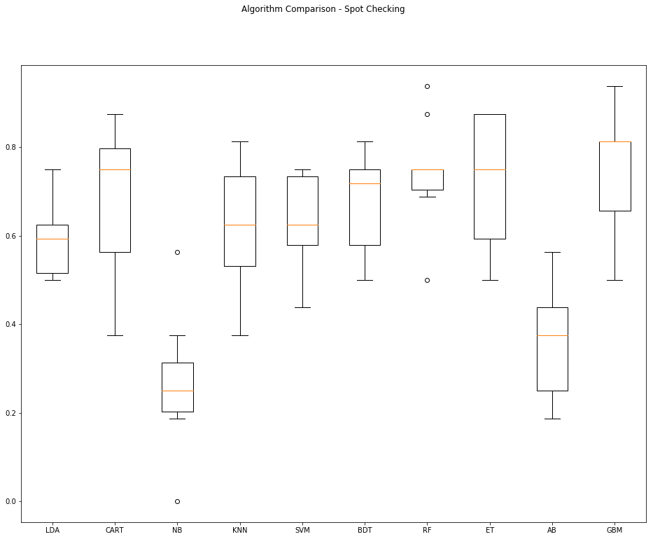

```python
fig = pyplot.figure()
fig.suptitle('Algorithm Comparison - Spot Checking')
ax = fig.add_subplot(111)
pyplot.boxplot(results)
ax.set_xticklabels(names)
pyplot.show()
```

## Section 5 - Improve Accuracy

After we achieve a short list of machine learning algorithms with good level of accuracy, we can leverage ways to improve the accuracy of the models.

### 5.a) Algorithm Tuning

```python
# Set up the comparison array
results = []
names = []
```

```python
# Tuning algorithm #1 - Bagged Decision Trees
startTimeModule = datetime.now()
paramGrid1 = dict(n_estimators=numpy.array([10,25,50,100,200]))
model1 = BaggingClassifier(random_state=seedNum)
kfold = KFold(n_splits=num_folds, random_state=seedNum)
grid1 = GridSearchCV(estimator=model1, param_grid=paramGrid1, scoring=scoring, cv=kfold)
grid_result1 = grid1.fit(X_train, Y_train)

print("Best: %f using %s" % (grid_result1.best_score_, grid_result1.best_params_))
results.append(grid_result1.cv_results_['mean_test_score'])
names.append('BDT')
means = grid_result1.cv_results_['mean_test_score']
stds = grid_result1.cv_results_['std_test_score']
params = grid_result1.cv_results_['params']
for mean, stdev, param in zip(means, stds, params):
    print("%f (%f) with: %r" % (mean, stdev, param))
print ('Model training time:',(datetime.now() - startTimeModule))
```

```
Best: 0.737500 using {'n_estimators': 25}
0.700000 (0.114564) with: {'n_estimators': 10}
0.737500 (0.096014) with: {'n_estimators': 25}
0.737500 (0.103833) with: {'n_estimators': 50}
0.737500 (0.127475) with: {'n_estimators': 100}
0.737500 (0.111102) with: {'n_estimators': 200}
Model training time: 0:00:04.974937
```

```python
# Tuning algorithm #2 - Random Forest
startTimeModule = datetime.now()
paramGrid2 = dict(n_estimators=numpy.array([10,25,50,100,200]))
model2 = RandomForestClassifier(random_state=seedNum)
kfold = KFold(n_splits=num_folds, random_state=seedNum)
grid2 = GridSearchCV(estimator=model2, param_grid=paramGrid2, scoring=scoring, cv=kfold)
grid_result2 = grid2.fit(X_train, Y_train)

print("Best: %f using %s" % (grid_result2.best_score_, grid_result2.best_params_))
results.append(grid_result2.cv_results_['mean_test_score'])
names.append('RF')
means = grid_result2.cv_results_['mean_test_score']
stds = grid_result2.cv_results_['std_test_score']
params = grid_result2.cv_results_['params']
for mean, stdev, param in zip(means, stds, params):
    print("%f (%f) with: %r" % (mean, stdev, param))
print ('Model training time:',(datetime.now() - startTimeModule))
```

```
Best: 0.762500 using {'n_estimators': 100}
0.756250 (0.098623) with: {'n_estimators': 10}
0.718750 (0.125779) with: {'n_estimators': 25}
0.750000 (0.121835) with: {'n_estimators': 50}
0.762500 (0.127475) with: {'n_estimators': 100}
0.762500 (0.117925) with: {'n_estimators': 200}
Model training time: 0:00:04.568130
```

```python
# Tuning algorithm #3 - Stochastic Gradient Boosting
startTimeModule = datetime.now()
paramGrid3 = dict(n_estimators=numpy.array([10,25,50,100,200]))
model3 = GradientBoostingClassifier(random_state=seedNum)
kfold = KFold(n_splits=num_folds, random_state=seedNum)
grid3 = GridSearchCV(estimator=model3, param_grid=paramGrid3, scoring=scoring, cv=kfold)
grid_result3 = grid3.fit(X_train, Y_train)

print("Best: %f using %s" % (grid_result3.best_score_, grid_result3.best_params_))
results.append(grid_result3.cv_results_['mean_test_score'])
names.append('GBM')
means = grid_result3.cv_results_['mean_test_score']
stds = grid_result3.cv_results_['std_test_score']
params = grid_result3.cv_results_['params']
for mean, stdev, param in zip(means, stds, params):
    print("%f (%f) with: %r" % (mean, stdev, param))
print ('Model training time:',(datetime.now() - startTimeModule))
```

```
Best: 0.756250 using {'n_estimators': 200}
0.631250 (0.141006) with: {'n_estimators': 10}
0.712500 (0.112500) with: {'n_estimators': 25}
0.743750 (0.123269) with: {'n_estimators': 50}
0.750000 (0.134048) with: {'n_estimators': 100}
0.756250 (0.129452) with: {'n_estimators': 200}
Model training time: 0:00:11.364643
```

### 5.b) Compare Algorithms After Tuning

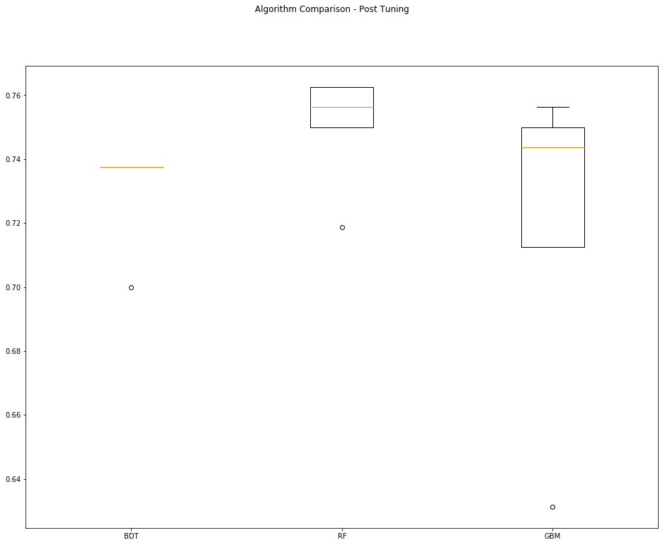

```python
fig = pyplot.figure()
fig.suptitle('Algorithm Comparison - Post Tuning')
ax = fig.add_subplot(111)
pyplot.boxplot(results)
ax.set_xticklabels(names)
pyplot.show()
```

## Section 6 - Finalize Model

Once we have narrow down to a model that we believe can make accurate predictions on unseen data, we are ready to finalize it. Finalizing a model may involve sub-tasks such as:

- Using an optimal model tuned to make predictions on unseen data.
- Creating a standalone model using the tuned parameters
- Saving an optimal model to file for later use.

### 6.a) Predictions on validation dataset

```python
model = RandomForestClassifier(n_estimators=100, random_state=seedNum)
model.fit(X_train, Y_train)
predictions = model.predict(X_validation)
print(accuracy_score(Y_validation, predictions))
print(confusion_matrix(Y_validation, predictions))
print(classification_report(Y_validation, predictions))
```

```
0.7962962962962963
[[17  1  1  0  0  0]
 [ 1 16  0  0  0  1]
 [ 1  2  1  0  0  0]
 [ 0  3  0  2  0  0]
 [ 0  1  0  0  2  0]
 [ 0  0  0  0  0  5]]
             precision    recall  f1-score   support

        1.0       0.89      0.89      0.89        19
        2.0       0.70      0.89      0.78        18
        3.0       0.50      0.25      0.33         4
        5.0       1.00      0.40      0.57         5
        6.0       1.00      0.67      0.80         3
        7.0       0.83      1.00      0.91         5

avg / total       0.81      0.80      0.78        54
```

### 6.b) Create standalone model on entire training dataset

```python
startTimeModule = datetime.now()
finalModel = RandomForestClassifier(n_estimators=100)
finalModel.fit(X_entire, Y_entire)
print ('Model training time:',(datetime.now() - startTimeModule))
```

```
Model training time: 0:00:00.128870
```

### 6.c) Save model for later use

```python
# modelName = 'finalModel_BinaryClass.sav'
# dump(finalModel, modelName)

print ('Total time for the script:',(datetime.now() - startTimeScript))
```

```
Total time for the script: 0:00:32.955446
```